# Linear Models S431 Final Presentation:

Exploring the Relationship between Motor Skills and Social Deficits in Children

Alli, Nick, Thomas

12/4/2019

# Study Details & Relevant Background Information

- Autism (ASD) and Attention Deficit/Hyperactivity Disorder (ADHD) are frequently observed in children, but are still not fully understood.
  - It is known that children with developmental disorders suffer from motor impairment concurrent with social deficits associated with their respective diagnoses(1,2). The extent and cause of this correlation merits further research.
- Kennedy Krieger Institute(KKI) Study: Data Collected for Investigation and Analysis:

  ```
     Social Responsiveness Scale Questionnaire (SRS), Movement Assessment Battery
     for Children (mABC), Wechsler Intelligence Scale for Children (WISC), Gender,
     Age,Handedness (quantified by Edinburgh Handedness Integer), Primary and
     Secondary Diagnosis
  ```

- We want to investigate the overall association between social deficits and motor skills for each diagnosis group.
  - Primary Endpoint: What motor skills are associated with SRS scores for each diagnosis group.
  - Secondary Endpoint: What factors influence this association?

# Methods: Cleaning Data

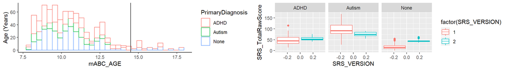

- Standardized the test scores from SRS Version 2 so the mean and varaince match that of Version 1, using linear equating method<sup>1</sup>
- Removed Observations that had N/A values for either SRS_TotalRawScore or mABC_TotalStandardScore, reducing the total number of observations to 568.
- Converted all the WISC scores to the GAI scale for comparability across versions

| Primary | Count | Avg Age | Males | Females | Left | Mixed | Right |
| --- | --- | --- | --- | --- | --- | --- | --- |
| ASD | 138 | 10.236 | 116 | 22 | 12 | 19 | 106 |
| ADHD | 176 | 9.6908 | 124 | 52 | 20 | 14 | 142 |
| TD | 254 | 10.2146 | 185 | 69 | 20 | 24 | 209 |

1 Equating Test Scores (without IRT) Second Edition Page 14, Samual A Livingston.

# Methods: Exploring Motor Skill’s Association with Social Deficits

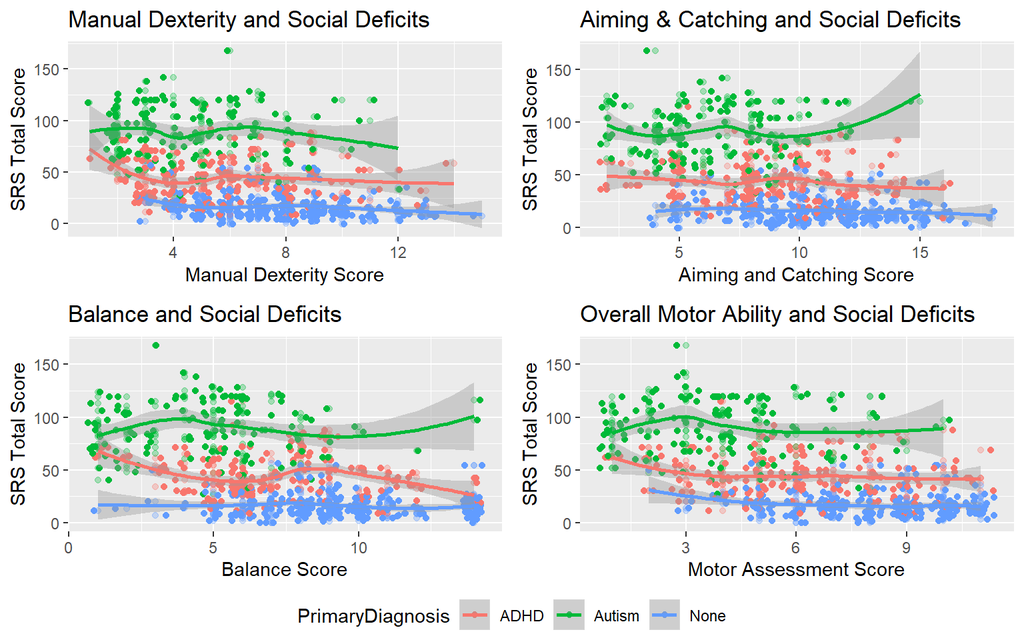

- Key Takeaway: The association between motor skills and social deficits is different for each of the subcomponents of the mABC, and differ for children with different primary diagnoses.

# Methods: Other Variables

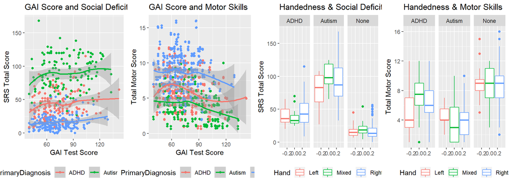

- Key Takeaways:

# Proposed Models

$$\text{E[Social Deficit Score]} = \textbf{X} * \boldsymbol{\beta} \\
where: \\
\boldsymbol{\beta} = \begin{bmatrix}
\text{Intercept} \\
\text{Balance Score} \\
\text{Aiming And Catching Score} \\
\text{EdinburgHandedness_Integer} \\
\text{GAI} \\
\text{Gender Male} \\
\text{mABC_AGE}
\end{bmatrix}$$

# Results: Typically Developing

$$\boldsymbol{\beta} = \begin{bmatrix}
\text{Intercept} \\
\text{Balance Score} \\
\text{Aiming And Catching Score} \\
\text{EdinburgHandedness_Integer} \\
\text{GAI} \\
\text{Gender Male} \\
\text{mABC_AGE}
\end{bmatrix}
=
\begin{bmatrix}
4.198941 \\
-0.017533 \\
-0.038443 \\
-0.258429 \\
0.010782 \\
-0.045793 \\
-0.032151
\end{bmatrix}
=
\begin{bmatrix}
3.4107 - 4.987 \\
-0.07434 - 0.03927 \\
-0.10123 - 0.02435 \\
-0.57488 - 0.05802 \\
0.0003657 - 0.0212 \\
-0.44617 - 0.3546 \\
-0.177092 - 0.1128
\end{bmatrix}$$

$$P-Value=0.3062$$
$$Adjusted R-Squared: 0.01153$$

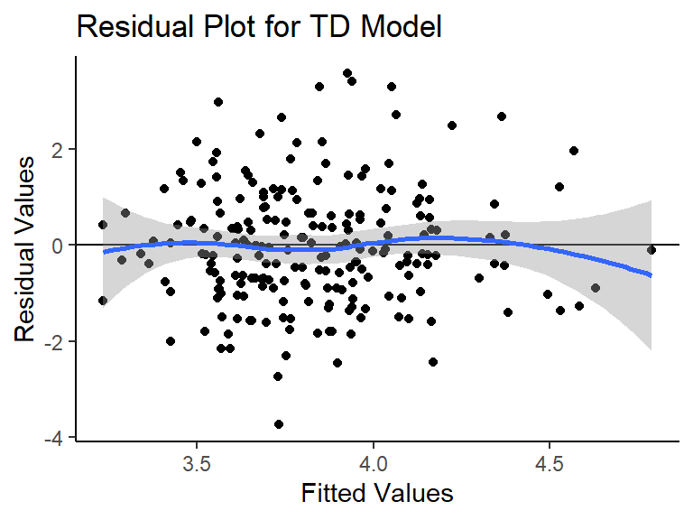

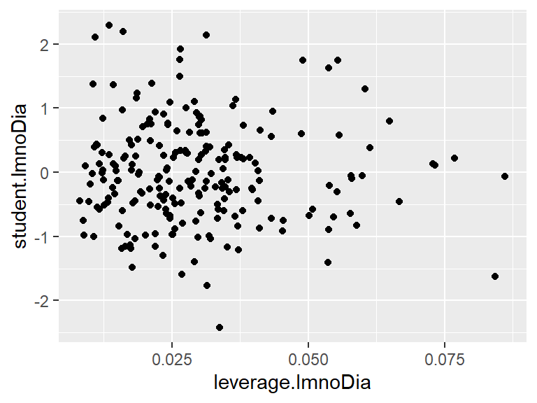

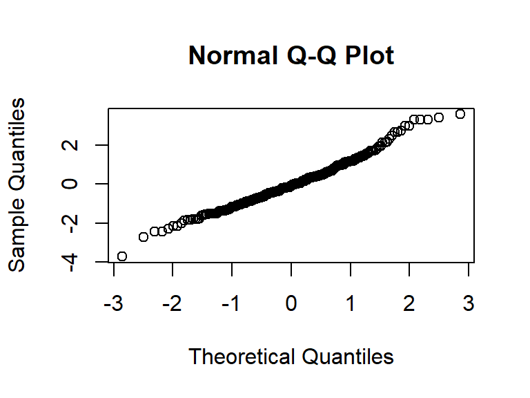

# Results: ADHD

$$\boldsymbol{\beta} = \begin{bmatrix}
\text{Intercept} \\
\text{Balance Score} \\
\text{Aiming And Catching Score} \\
\text{EdinburgHandedness_Integer} \\
\text{GAI} \\
\text{ADHD Subtype Inattentive} \\
\text{Gender Male} \\
\text{mABC_AGE}
\end{bmatrix}
=
\begin{bmatrix}
7.2115 \\
-0.0408 \\
-0.0646 \\
0.3292 \\
0.0085 \\
-1.266 \\
-0.175 \\
-0.049
\end{bmatrix}
=
\begin{bmatrix}
6.11 - 8.24 \\
-0.08 - (-0.0042) \\
-0.1033 - (-0.0433) \\
0.1356 - 0.5182 \\
0.00261 - 0.0144 \\
-1.563711 - (-0.9777) \\
-0.414 - (0.078) \\
-0.1403 - 0.0456
\end{bmatrix}$$

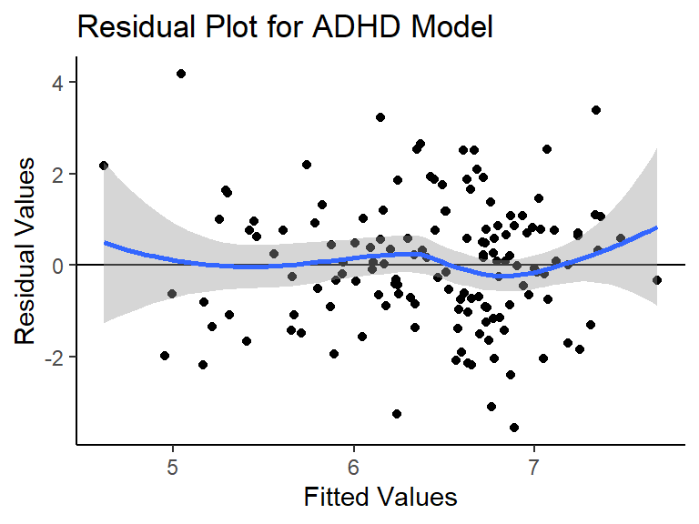

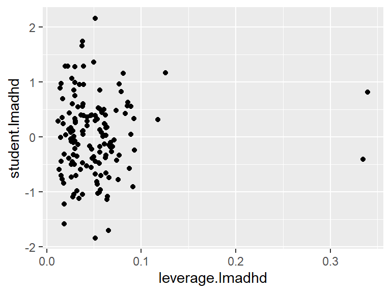

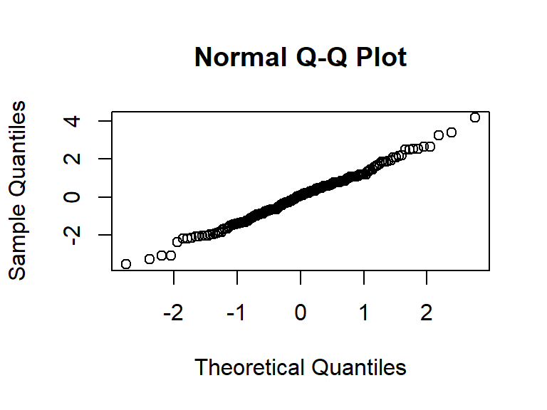

$$H_0: \text{Just Balance and Catching is Sufficient} \\
H_1: \text{Full Model is Sufficient} \\
\text{Under the null we got an F-statistic of 5.905 where} \ F \sim F_{4,165} \\
\text{which gives us a p-value of .00018 with an} \ \alpha = .05 \ \text{we reject the null} \\
\text{and believe that we should keep every coefficient in the full model}$$

# Results: ASD

$$\boldsymbol{\beta} = \begin{bmatrix}
\text{Intercept} \\
\text{Balance Score} \\
\text{Aiming And Catching Score} \\
\text{EdinburgHandedness_Integer} \\
\text{GAI} \\
\text{ADHD Subtype Inattentive} \\
\text{Gender Male} \\
\text{mABC_AGE}
\end{bmatrix}
=
\begin{bmatrix}
7.684094 \\
0.021461 \\
-0.006293 \\
0.246669 \\
0.008037 \\
0.513015 \\
-0.378386 \\
0.059798
\end{bmatrix}
=
\begin{bmatrix}
5.758 - 9.609 \\
-0.0824 - 0.125 \\
-0.1056 - 0.093 \\
-0.2285 - 0.7218 \\
-0.00295 - 0.019 \\
-2.2902 - 3.3162 \\
-1.05821 - 0.30144 \\
-0.11999 - 0.23959
\end{bmatrix}$$

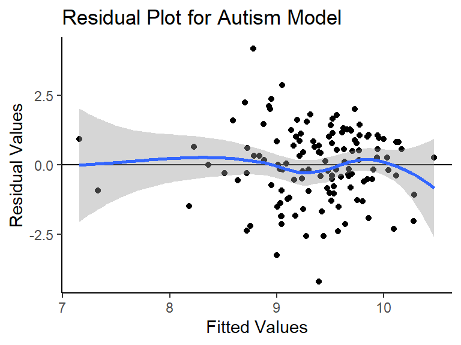

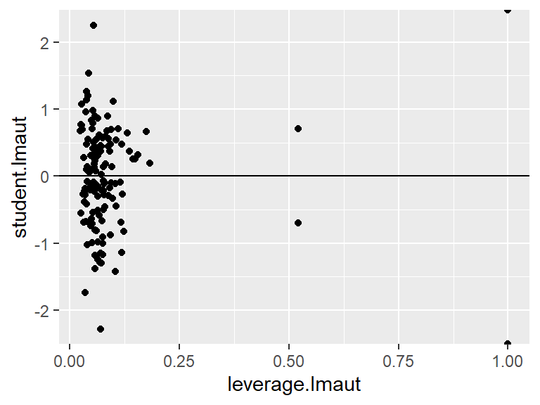

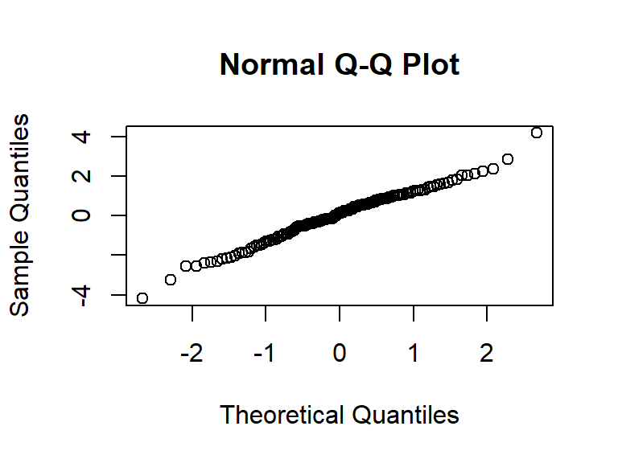

# Concluding Thoughts

- For Typically Developing Subjects could not make distinguished correlation between motor ability and Social Deficit
- Subjects with ADHD had a slight correlation, Increased Motor skills corelated with less social deficits
- Subjects with Autism had indesernable relationship between Motor skills and Social Deficits.